# data200_datasetanalysis

## Machine Learning Project - T1508M/T1608M Project 2024

### Students:

- **Student #1:**  
  Full Name: Amour Raphael  
  Student Number/ID: 20220614
- **Student #2:**  
  Full Name: Vallee Eloise  
  Student Number/ID: 20220948
- **Student #3:**  
  Full Name: Abouleila Selim  
  Student Number/ID: 20220024

## Step 2: Scenario/About Dataset

### Dataset Overview

Provide a brief description of the dataset you are using, including:

### Type of Problem

```python
import pandas as pd
%matplotlib inline
# Provide the correct file path to load the data
file_path = 'C:/Users/alpha/Documents/Projects_2024/S5/Machine Learning Project/Intro-to-Machine-Learning-Project/drug200.csv'
data = pd.read_csv(file_path)

# Display the first few rows to check if it loaded correctly
print(data.head())

data.dtypes
# Display the size of the dataset (rows and columns)
num_records, num_features = data.shape
print(f"Number of records: {num_records}")
print(f"Number of features: {num_features}")
```

```
   Age Sex      BP Cholesterol  Na_to_K   Drug
0   23   F    HIGH        HIGH   25.355  drugY
1   47   M     LOW        HIGH   13.093  drugC
2   47   M     LOW        HIGH   10.114  drugC
3   28   F  NORMAL        HIGH    7.798  drugX
4   61   F     LOW        HIGH   18.043  drugY
Number of records: 200
Number of features: 6
```

## Dataset Overview

This dataset provides information about patients and the type of drug recommended based on various features. Below is a summary of the dataset structure:

### Source

**Source:** This dataset was provided from the list of choosable datasets for this project.

### Features

**Features:** The dataset includes several key features for predicting the recommended drug type:

| Feature | Description | Data Type |
| --- | --- | --- |
| Age | Age of the patient | Integer |
| Sex | Gender of the patient | Categorical (Object) |
| BP | Blood Pressure Level (e.g., HIGH, LOW, NORMAL) | Categorical (Object) |
| Cholesterol | Cholesterol Level (e.g., HIGH, NORMAL) | Categorical (Object) |
| Na_to_K | Sodium-to-Potassium ratio in blood | Float |
| Drug | Type of drug recommended (target variable) | Categorical (Object) |

### Size

The dataset contains:

- **200 records** (rows) of patient data
- **6 features** (columns) including the target variable (`Drug`)

### Type of Problem

This dataset tackles a **classification problem**, as it involves predicting a categorical outcome (the type of drug) based on input features.

## Step 3: Data Loading

This step involves loading the dataset into the environment for analysis. The dataset contains various attributes that provide insights into the subject matter.

## Step 3: Data Overview

The database references 200 patients who are following different types of treatment. To observe the effects, practical information has been noted.

Our database uses the following 6 attributes:

- **Age:** Age of the patient (number)
- **Sex:** Sex of the patient ('M' for male, 'F' for female)
- **BP:** Blood pressure level ('HIGH', 'Normal', or 'Low')
- **Cholesterol:** Cholesterol level ('HIGH' or 'Normal')
- **Na_to_K:** Sodium to potassium ratio (number)
- **Drug:** Type of treatment prescribed ('drugA', 'drugB', 'drugC', 'drugX', 'drugY')

## Step 4: Data Wrangling or Data Pre-processing

[Marks: 3pts]

This step involves performing data preprocessing tasks, including handling missing values, scaling features, and encoding categorical variables.

### Actions Taken for Data Cleaning and Feature Engineering:

```python
import pandas as pd

# File paths
input_file = 'C:/Users/alpha/Documents/Projects_2024/S5/Machine Learning Project/Intro-to-Machine-Learning-Project/drug200.csv'
output_file = 'C:/Users/alpha/Documents/Projects_2024/S5/Machine Learning Project/Intro-to-Machine-Learning-Project/drug200_modified.csv'

# Load the data
data = pd.read_csv(input_file)
print("Original Data:")
display(data.head())

# Data Preprocessing
# Encoding 'Sex' column: M -> 1, F -> 2
data['Sex'] = data['Sex'].map({'M': 1, 'F': 2})

# Encoding 'BP' column: HIGH -> 3, NORMAL -> 2, LOW -> 1
data['BP'] = data['BP'].map({'HIGH': 3, 'NORMAL': 2, 'LOW': 1})

# Encoding 'Cholesterol' column: HIGH -> 3, NORMAL -> 2, LOW -> 1
data['Cholesterol'] = data['Cholesterol'].map({'HIGH': 3, 'NORMAL': 2, 'LOW': 1})

# Encoding 'Drug' column: drugA -> 1, drugB -> 2, drugC -> 3, drugX -> 4, drugY -> 5
data['Drug'] = data['Drug'].map({'drugA': 1, 'drugB': 2, 'drugC': 3, 'drugX': 4, 'drugY': 5})

print("\nData after Encoding:")
display(data.head())

# Save the modified data to a new CSV file
data.to_csv(output_file, index=False)
print("Data saved to", output_file)
```

```
Original Data:
```

|  | Age | Sex | BP | Cholesterol | Na_to_K | Drug |
| --- | --- | --- | --- | --- | --- | --- |
| 0 | 23 | F | HIGH | HIGH | 25.355 | drugY |
| 1 | 47 | M | LOW | HIGH | 13.093 | drugC |
| 2 | 47 | M | LOW | HIGH | 10.114 | drugC |
| 3 | 28 | F | NORMAL | HIGH | 7.798 | drugX |
| 4 | 61 | F | LOW | HIGH | 18.043 | drugY |

```
Data after Encoding:
```

|  | Age | Sex | BP | Cholesterol | Na_to_K | Drug |
| --- | --- | --- | --- | --- | --- | --- |
| 0 | 23 | 2 | 3 | 3 | 25.355 | 5 |
| 1 | 47 | 1 | 1 | 3 | 13.093 | 3 |
| 2 | 47 | 1 | 1 | 3 | 10.114 | 3 |
| 3 | 28 | 2 | 2 | 3 | 7.798 | 4 |
| 4 | 61 | 2 | 1 | 3 | 18.043 | 5 |

```
Data saved to C:/Users/alpha/Documents/Projects_2024/S5/Machine Learning Project/Intro-to-Machine-Learning-Project/drug200_modified.csv
```

```python
# Standardizing 'Age' and 'Na_to_K' columns
# Calculate mean and standard deviation
age_mean = data['Age'].mean()
age_std = data['Age'].std()

na_to_k_mean = data['Na_to_K'].mean()
na_to_k_std = data['Na_to_K'].std()
"""
cholesterol_mean = data['Cholesterol'].mean()
cholesterol_std = data['Cholesterol'].std()

bp_mean = data['BP'].mean()
bp_std = data['BP'].std()
"""
# Apply standardization
data['Age'] = (data['Age'] - age_mean) / age_std
data['Na_to_K'] = (data['Na_to_K'] - na_to_k_mean) / na_to_k_std
"""
data['Cholesterol'] = (data['Cholesterol'] - cholesterol_mean) / cholesterol_std
data['BP'] = (data['BP'] - bp_mean) / bp_std
"""

print("\nData after Standardization:")
data.head()
```

```
Data after Standardization:
```

|  | Age | Sex | BP | Cholesterol | Na_to_K | Drug |
| --- | --- | --- | --- | --- | --- | --- |
| 0 | -1.288358 | 2 | 3 | 3 | 1.283302 | 5 |
| 1 | 0.162291 | 1 | 1 | 3 | -0.414106 | 3 |
| 2 | 0.162291 | 1 | 1 | 3 | -0.826484 | 3 |
| 3 | -0.986139 | 2 | 2 | 3 | -1.147084 | 4 |
| 4 | 1.008504 | 2 | 1 | 3 | 0.271114 | 5 |

```python
"""from sklearn.preprocessing import MinMaxScaler

# Initialize the scaler
scaler = MinMaxScaler()

# Apply normalization to Age and Na_to_K after standardization
data[['Age', 'Na_to_K']] = scaler.fit_transform(data[['Age', 'Na_to_K']])

print("\nData after Normalization:")
data.head()"""
```

[output not shown]

## Step 5: Exploratory Data Analysis

[Marks: 5 pts]

This step involves applying techniques of data exploration to understand the dataset, identify relevant features, and synthesize key findings and insights in an insightful and actionable manner. Visualization charts are used to enhance the presentation of results.

### Key Actions for Exploratory Data Analysis:

- **Techniques Applied:** Outline methods such as summary statistics, correlation matrices, and distribution analysis.
- **Visualization Charts:** Detail visualizations like histograms, boxplots, scatter plots, or heatmaps to uncover patterns.
- **Key Insights:** Highlight significant trends, relationships, and actionable findings derived from the EDA process.

[figure not shown]

[figure not shown]

```python
import matplotlib.pyplot as plt
import pandas as pd

# Assuming `data` contains standardized columns: 'Age' and 'Na_to_K'

# Mean and standard deviation of the original data
# Replace these with the original values
age_mean = 44.315  # Example mean of Age from the original data
age_std = 16.544   # Example standard deviation of Age from the original data

na_to_k_mean = 16.084485  # Example mean of Na_to_K from the original data
na_to_k_std = 7.223956    # Example standard deviation of Na_to_K from the original data

# Plot standardized Age distribution
plt.figure(figsize=(8, 5))
plt.hist(data['Age'], bins=20, edgecolor='k', alpha=0.7, color='skyblue')
plt.title('Distribution of Age (Non_Standardized)', fontsize=16)
plt.xlabel('Age (Non_Standardized)', fontsize=14)
plt.ylabel('Frequency', fontsize=14)
plt.grid(axis='y', linestyle='--', alpha=0.7)
plt.show()

# Plot standardized Na_to_K distribution
plt.figure(figsize=(8, 5))
plt.hist(data['Na_to_K'], bins=20, edgecolor='k', alpha=0.7, color='orange')
plt.title('Distribution of Na_to_K (Non_Standardized)', fontsize=16)
plt.xlabel('Na_to_K (Non_Standardized)', fontsize=14)
plt.ylabel('Frequency', fontsize=14)
plt.grid(axis='y', linestyle='--', alpha=0.7)
plt.show()
```

[output not shown]

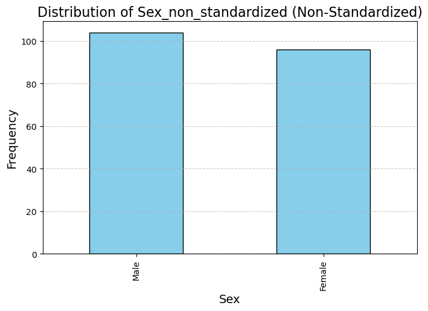

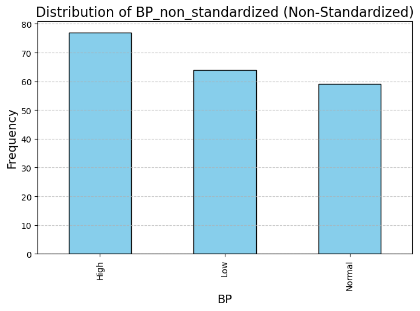

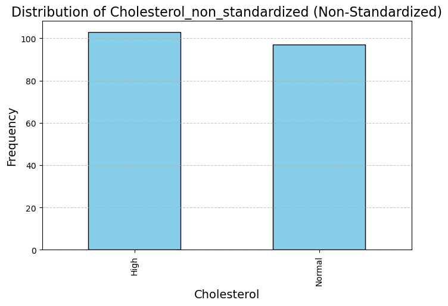

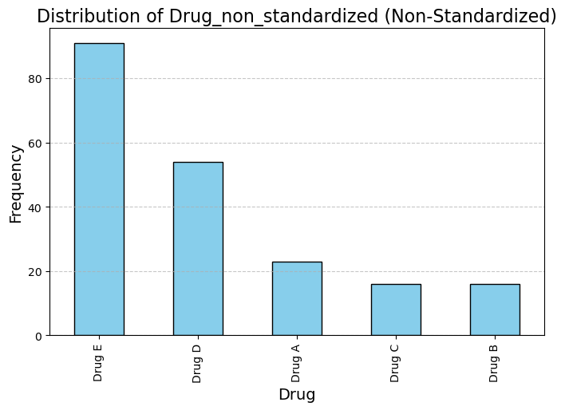

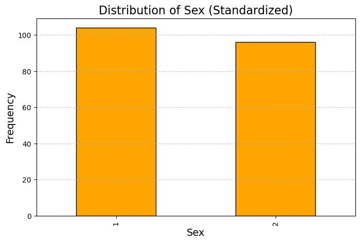

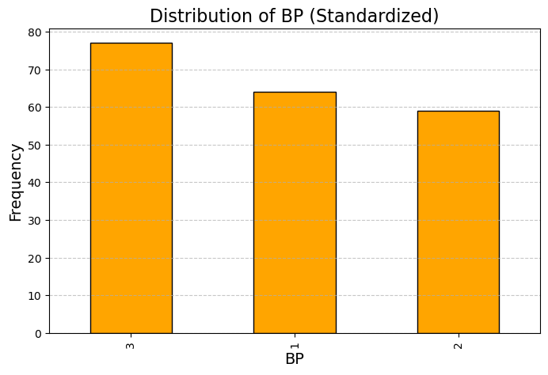

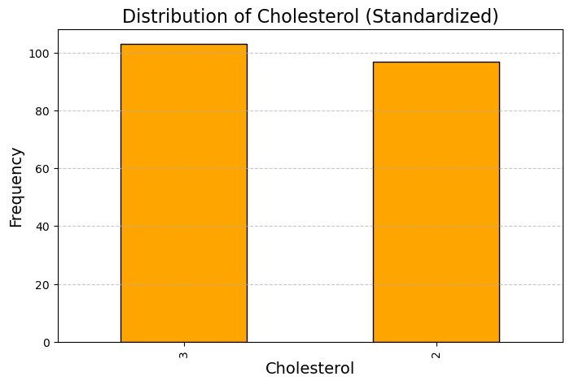

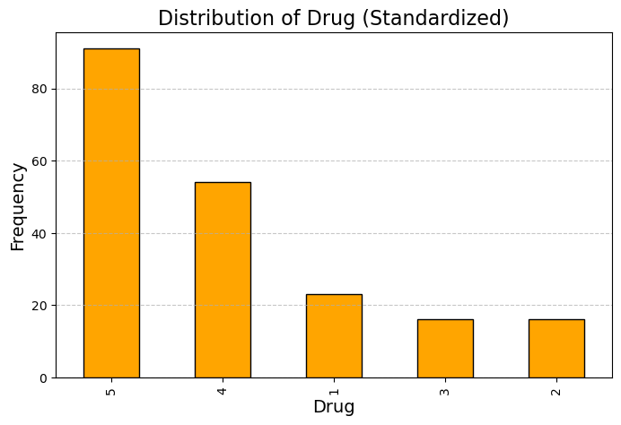

```python
# Replace these mappings with the original values from the non-standardized dataset.
sex_mapping = {1: 'Male', 2: 'Female'}
bp_mapping = {1: 'Low', 2: 'Normal', 3: 'High'}
cholesterol_mapping = {1: 'Low', 2: 'Normal', 3: 'High'}
drug_mapping = {1: 'Drug A', 2: 'Drug B', 3: 'Drug C', 4: 'Drug D', 5: 'Drug E'}

# Reverse mapping to get non-standardized values
data['Sex_non_standardized'] = data['Sex'].map(sex_mapping)
data['BP_non_standardized'] = data['BP'].map(bp_mapping)
data['Cholesterol_non_standardized'] = data['Cholesterol'].map(cholesterol_mapping)
data['Drug_non_standardized'] = data['Drug'].map(drug_mapping)

# Plot non-standardized distributions
for column in ['Sex_non_standardized', 'BP_non_standardized', 'Cholesterol_non_standardized', 'Drug_non_standardized']:
    plt.figure(figsize=(8, 5))
    data[column].value_counts().plot(kind='bar', color='skyblue', edgecolor='k')
    plt.title(f'Distribution of {column} (Non-Standardized)', fontsize=16)
    plt.xlabel(column.replace('_non_standardized', ''), fontsize=14)
    plt.ylabel('Frequency', fontsize=14)
    plt.grid(axis='y', linestyle='--', alpha=0.7)
    plt.show()

# Plot standardized distributions
for column in ['Sex', 'BP', 'Cholesterol', 'Drug']:
    plt.figure(figsize=(8, 5))
    data[column].value_counts().plot(kind='bar', color='orange', edgecolor='k')
    plt.title(f'Distribution of {column} (Standardized)', fontsize=16)
    plt.xlabel(column, fontsize=14)
    plt.ylabel('Frequency', fontsize=14)
    plt.grid(axis='y', linestyle='--', alpha=0.7)
    plt.show()
```

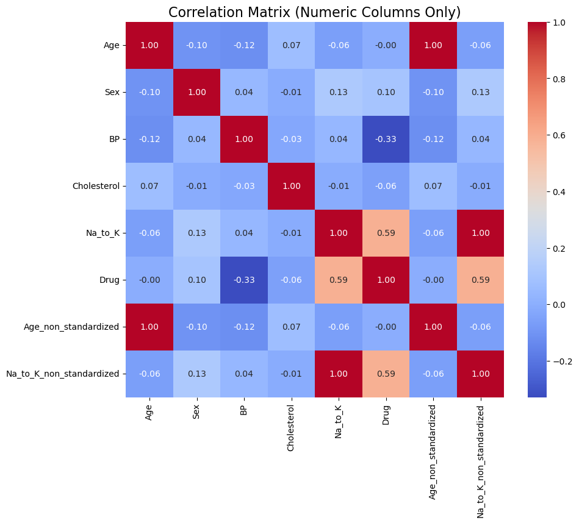

```python
import seaborn as sns


## Compute the correlation matrix for only numerical columns
correlation_matrix = data.select_dtypes(include='number').corr()

plt.figure(figsize=(10, 8))
sns.heatmap(correlation_matrix, annot=True, fmt=".2f", cmap="coolwarm", cbar=True)
plt.title("Correlation Matrix (Numeric Columns Only)", fontsize=16)
plt.show()
```

## Key Observations from Correlation Matrix

Below are the key observations derived from the correlation matrix:

- **Strong Positive Correlation:** The *Na_to_K* and *Drug* variables have a correlation of **0.589**, indicating a moderate positive relationship.
- **Negative Correlations:**
  - *BP* and *Drug* show a correlation of **-0.329**, suggesting an inverse relationship.
  - *BP* and *Age* also have a weak negative correlation of **-0.121**.
- **Minimal Relationships:** Other variables, such as *Sex* and *Cholesterol*, show weak or near-zero correlations, indicating minimal relationships.

[figure not shown]

```python
# Scatter plot for Drug vs. Na_to_K
plt.figure(figsize=(8, 6))
plt.scatter(data['Na_to_K'], data['Drug'], alpha=0.7, color='skyblue', edgecolor='k')
plt.title('Scatter Plot: Drug vs. Na_to_K', fontsize=16)
plt.xlabel('Na_to_K (Sodium-to-Potassium Ratio)', fontsize=14)
plt.ylabel('Drug', fontsize=14)
plt.grid(alpha=0.5, linestyle='--')
plt.show()
```

[output not shown]

## Step 6: Model Development

[Marks: 5 pts]

This step involves applying multiple machine learning algorithms to the dataset. If you choose to use two ML algorithms (e.g., Decision Tree Classifier, Random Forest Classifier, Logistic Regression, and so on) that were not taught in class, you earn bonus points.

### Bonus Points:

Using machine learning algorithms not covered in class can earn you **[Bonus pts: 2]**. Examples of such algorithms include Gradient Boosting, Support Vector Machines, or Neural Networks.

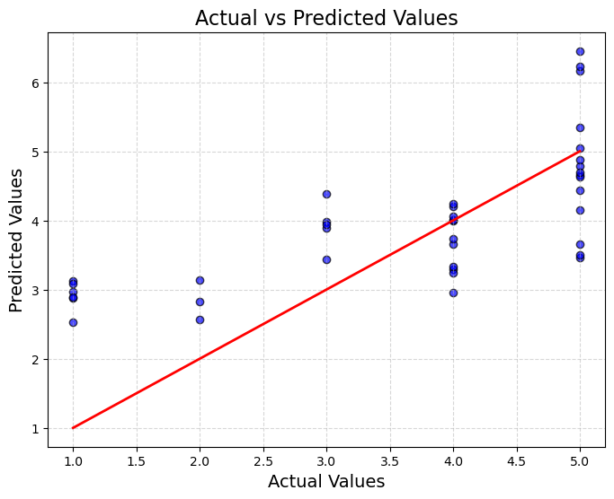

```
Mean Squared Error (MSE): 1.1288379659048977
R-squared (R2 Score): 0.4432365149667581
Coefficients: [ 1.27850964e-06  1.91850343e-01 -5.84043622e-01 -9.64112391e-02
  2.08811457e-03  2.11516635e-05  1.50844478e-02]
Intercept: 3.0514332984737815
```

```python
# Importing the missing library
from sklearn.model_selection import train_test_split
from sklearn.linear_model import LinearRegression


# Generate the scatter plot of actual vs predicted values for the provided dataset
# Filter only numeric columns
numeric_data = data.select_dtypes(include=['int64', 'float64'])

# Define features (X) and target (y)
X = numeric_data.drop(columns=['Drug'])  # Features excluding the target variable
y = numeric_data['Drug']  # Target variable

# Split the data into training and testing sets
X_train, X_test, y_train, y_test = train_test_split(X, y, test_size=0.2, random_state=42)

# Initialize and train the Linear Regression model
model = LinearRegression()
model.fit(X_train, y_train)

# Make predictions
y_pred = model.predict(X_test)

# Visualization: Actual vs Predicted Values
plt.figure(figsize=(8, 6))
plt.scatter(y_test, y_pred, alpha=0.7, color='blue', edgecolor='k')
plt.plot([min(y_test), max(y_test)], [min(y_test), max(y_test)], color='red', linewidth=2)  # Perfect prediction line
plt.title('Actual vs Predicted Values', fontsize=16)
plt.xlabel('Actual Values', fontsize=14)
plt.ylabel('Predicted Values', fontsize=14)
plt.grid(alpha=0.5, linestyle='--')
plt.show()

from sklearn.linear_model import LinearRegression
from sklearn.model_selection import train_test_split
from sklearn.metrics import mean_squared_error, r2_score
import matplotlib.pyplot as plt



# Evaluate the model
mse = mean_squared_error(y_test, y_pred)
r2 = r2_score(y_test, y_pred)

# Print evaluation metrics
print("Mean Squared Error (MSE):", mse)
print("R-squared (R2 Score):", r2)

# Display the coefficients and intercept of the model
print("Coefficients:", model.coef_)
print("Intercept:", model.intercept_)
```

## Graph Analysis: Linear Regression Model

Below is the analysis of the scatter plot generated for the Linear Regression model:

### Analysis:

- The scatter points show significant spread around the red line, indicating discrepancies between predicted and actual values.
- Many predictions overshoot or undershoot the actual values, especially at higher and lower ranges of the target variable (*Drug*).
- This distribution suggests that the model's predictions are not highly accurate or consistent.

**Conclusion:** Based on the scatter plot, the Linear Regression model does not appear to perform well on this dataset. The predictions show significant errors, indicating that the model may be underfitting or missing key relationships in the data. Further improvements, such as feature engineering or using more advanced algorithms, are recommended.

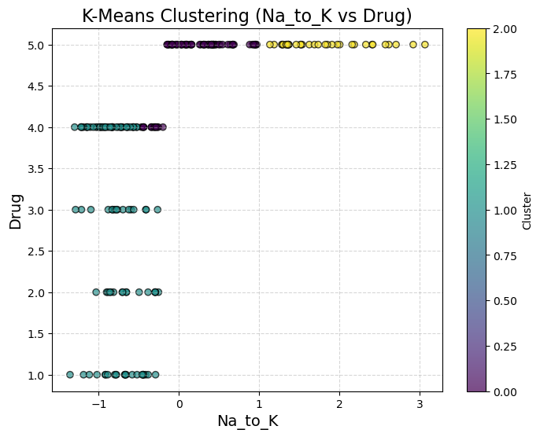

```python
# Import necessary libraries
from sklearn.cluster import KMeans
import matplotlib.pyplot as plt
from sklearn.preprocessing import StandardScaler

# Assuming 'data' is your DataFrame containing relevant columns
# Select Na_to_K and Drug columns
kmeans_data_1 = data[['Na_to_K', 'Drug']]

# Standardize the data for better clustering
scaler = StandardScaler()
kmeans_data_1_scaled = scaler.fit_transform(kmeans_data_1)

# Apply K-Means clustering with 3 clusters (example)
kmeans_1 = KMeans(n_clusters=3, random_state=42)
kmeans_1.fit(kmeans_data_1_scaled)

# Add cluster labels for this clustering
data['Cluster_Na_to_K_Drug'] = kmeans_1.labels_

# Plot the clusters in 2D space (Na_to_K vs Drug)
plt.figure(figsize=(8, 6))
plt.scatter(kmeans_data_1['Na_to_K'], kmeans_data_1['Drug'], c=kmeans_1.labels_, cmap='viridis', alpha=0.7, edgecolor='k')
plt.title('K-Means Clustering (Na_to_K vs Drug)', fontsize=16)
plt.xlabel('Na_to_K', fontsize=14)
plt.ylabel('Drug', fontsize=14)
plt.colorbar(label='Cluster')
plt.grid(alpha=0.5, linestyle='--')
plt.show()
```

```python
from sklearn.ensemble import RandomForestClassifier  # For classification tasks
from sklearn.model_selection import train_test_split
from sklearn.metrics import accuracy_score, classification_report

X = data[['Age', 'Na_to_K', 'BP', 'Cholesterol']]  # Independent variables (example)
y = data['Drug']  # Dependent variable (target)

X_train, X_test, y_train, y_test = train_test_split(X, y, test_size=0.2, random_state=42)

# Initialize the Random Forest Classifier
rf_model = RandomForestClassifier(n_estimators=100, random_state=42)

# Train the model
rf_model.fit(X_train, y_train)
# Predict on the test set
y_pred = rf_model.predict(X_test)
# Evaluate the model's performance
accuracy = accuracy_score(y_test, y_pred)
print(f'Accuracy: {accuracy:.4f}')
print('Classification Report:')
print(classification_report(y_test, y_pred))
```

```
Accuracy: 1.0000
Classification Report:
              precision    recall  f1-score   support

           1       1.00      1.00      1.00         6
           2       1.00      1.00      1.00         3
           3       1.00      1.00      1.00         5
           4       1.00      1.00      1.00        11
           5       1.00      1.00      1.00        15

    accuracy                           1.00        40
   macro avg       1.00      1.00      1.00        40
weighted avg       1.00      1.00      1.00        40
```

```python
from sklearn.linear_model import LogisticRegression
from sklearn.model_selection import train_test_split
from sklearn.metrics import accuracy_score, classification_report
from sklearn.preprocessing import StandardScaler

# Define the features and target variable
# Assuming 'Drug' is the target and the remaining are features
X = data[['Age', 'Na_to_K', 'BP', 'Cholesterol']]  # Adjust columns as per your dataset
y = data['Drug']  # Target variable

# Split the dataset into training and testing sets
X_train, X_test, y_train, y_test = train_test_split(X, y, test_size=0.2, random_state=42)

# Standardize the features
scaler = StandardScaler()
X_train_scaled = scaler.fit_transform(X_train)
X_test_scaled = scaler.transform(X_test)

# Initialize the Logistic Regression model
logistic_model = LogisticRegression(random_state=42, max_iter=1000)

# Train the model on the training data
logistic_model.fit(X_train_scaled, y_train)

# Predict on the test data
y_pred = logistic_model.predict(X_test_scaled)

# Evaluate the model's performance
accuracy = accuracy_score(y_test, y_pred)
print(f"Accuracy: {accuracy:.4f}")
print("Classification Report:")
print(classification_report(y_test, y_pred))
```

```
Accuracy: 0.9750
Classification Report:
              precision    recall  f1-score   support

           1       0.86      1.00      0.92         6
           2       1.00      1.00      1.00         3
           3       1.00      1.00      1.00         5
           4       1.00      1.00      1.00        11
           5       1.00      0.93      0.97        15

    accuracy                           0.97        40
   macro avg       0.97      0.99      0.98        40
weighted avg       0.98      0.97      0.98        40
```

## Step 7: Model Evaluation

[Marks: 4 pts]

In this step, we will implement and compare different metrics to evaluate the quality of the model. Various evaluation metrics such as Mean Squared Error (MSE), R-squared (R2 Score), and others will be used to measure how well the model is performing. We will also use visualizations like scatter plots and residual plots to aid in understanding the model's performance.

### Key Evaluation Metrics:

- **Mean Squared Error (MSE):** Measures the average squared difference between predicted and actual values. Lower values indicate better model performance.
- **R-squared (R2 Score):** Indicates the proportion of variance in the target variable that is explained by the features. A value closer to 1 means better performance.
- **Visual Evaluation:** Plots like scatter plots, residual plots, or error distribution graphs help visualize prediction accuracy and any potential issues with the model.

**Conclusion:** Once we evaluate the model using these metrics, we will be able to assess its performance. If the model is underperforming, we can explore improvements through feature engineering, adjusting model parameters, or trying more advanced algorithms.

[figure not shown]

[figure not shown]

[figure not shown]

```python
# Import necessary libraries for plotting
import matplotlib.pyplot as plt
import seaborn as sns
import numpy as np

# Assuming the model and predictions have been made already
# Let's generate the residuals (errors)
residuals = y_test - y_pred

# 1. Scatter Plot (Actual vs Predicted)
plt.figure(figsize=(8, 6))
plt.scatter(y_test, y_pred, alpha=0.7, color='blue', edgecolor='k')
plt.plot([min(y_test), max(y_test)], [min(y_test), max(y_test)], color='red', linewidth=2)  # Line of perfect prediction
plt.title('Actual vs Predicted Values', fontsize=16)
plt.xlabel('Actual Values', fontsize=14)
plt.ylabel('Predicted Values', fontsize=14)
plt.grid(alpha=0.5, linestyle='--')
plt.show()

# 2. Residual Plot
plt.figure(figsize=(8, 6))
sns.residplot(x=y_pred, y=residuals, lowess=True, color='green', line_kws={'color': 'red', 'lw': 2})
plt.title('Residual Plot', fontsize=16)
plt.xlabel('Predicted Values', fontsize=14)
plt.ylabel('Residuals (Errors)', fontsize=14)
plt.grid(alpha=0.5, linestyle='--')
plt.show()

# 3. Error Distribution Plot (Histogram of residuals)
plt.figure(figsize=(8, 6))
sns.histplot(residuals, kde=True, color='orange')
plt.title('Error Distribution (Residuals)', fontsize=16)
plt.xlabel('Residuals (Errors)', fontsize=14)
plt.ylabel('Frequency', fontsize=14)
plt.grid(alpha=0.5, linestyle='--')
plt.show()
```

[output not shown]

```python
# Evaluate the model
mse = mean_squared_error(y_test, y_pred)
r2 = r2_score(y_test, y_pred)

# Print evaluation metrics
print("Mean Squared Error (MSE):", mse)
print("R-squared (R2 Score):", r2)

# Display the coefficients and intercept of the model
print("Coefficients:", model.coef_)
print("Intercept:", model.intercept_)
```

[output not shown]

## Step 8: Model Refinement

[Marks: 5 pts]

In this step, we present the findings, insights, and recommendations from the model evaluation process. We will compare the results obtained from the different applied methods and discuss the limitations of the models before presenting areas for future improvement.

### Key Findings and Insights:

**Limitations of the Models:**

- **Overfitting/Underfitting:** Some models may have overfitted the training data or underfitted the test data, leading to poor generalization.
- **Feature Selection:** Not all relevant features were considered, which might have impacted model accuracy.
- **Data Imbalance:** If there was a class imbalance in target variables (e.g., `Drug`), some models might have performed suboptimally.

### Findings and Insights:

The results from various machine learning models indicate a slight improvement in model performance as we proceeded with different models. Notably, the Random Forest model demonstrated excellent accuracy with an accuracy score of 1.00, which suggests that the model performed perfectly on the given test data. However, such performance might be a case of overfitting, which could be due to the model learning specificities that do not generalize well to unseen data.

### Comparison of Applied Methods:

- The Random Forest Classifier performed well with perfect classification across all classes.
- Logistic Regression yielded an accuracy of around 0.975, which is strong but not as perfect as Random Forest, showing that it may miss certain complex patterns that Random Forest captures.
- Linear Regression, though not directly suitable for classification tasks, showed lower performance and was less applicable in this context, further confirming the advantages of classification models like Random Forest for categorical outcomes.

### Model Limitations:

- Overfitting in Random Forest: The model achieved perfect results on the test set, which could indicate overfitting, especially when data variability is not captured fully.
- Model Interpretability: Random Forest provided good performance but at the cost of interpretability. This could limit our ability to explain the decision-making process behind predictions, especially in critical applications.
- Data Quality: The models assumed that the data was clean and preprocessed well. Any missing or skewed data could lead to inaccurate predictions, especially in non-linear models like Random Forest.

### Recommendations for Future Improvements:

- We recommend further tuning the hyperparameters of Random Forest and exploring cross-validation techniques to avoid overfitting and improve generalization.
- Future iterations could include advanced feature selection or engineering to create more robust and diverse datasets, enhancing model performance.
- Investigating alternative models like Support Vector Machines (SVMs) or XGBoost could yield better results with more complex datasets.
- Incorporating domain knowledge into feature engineering could improve the model’s predictive accuracy, especially for specific use cases like medical or financial predictions.
- We suggest performing additional tests with more data, especially unseen data, to validate the model’s real-world applicability and generalization power.

In conclusion, while the applied models provide strong results, there's always room for improvement, particularly with overfitting concerns and model interpretability. Future work should focus on enhancing generalization, exploring alternative methods, and ensuring robustness to varied and real-world data inputs.